# s-p-500-stock-analysis-for-beginners_ref

```python
# This Python 3 environment comes with many helpful analytics libraries installed
# It is defined by the kaggle/python Docker image: https://github.com/kaggle/docker-python
# For example, here's several helpful packages to load

# Input data files are available in the read-only "../input/" directory
# For example, running this (by clicking run or pressing Shift+Enter) will list all files under the input directory

import os
for dirname, _, filenames in os.walk('/kaggle/input'):
    for filename in filenames:
        print(os.path.join(dirname, filename))

# You can write up to 20GB to the current directory (/kaggle/working/) that gets preserved as output when you create a version using "Save & Run All"
# You can also write temporary files to /kaggle/temp/, but they won't be saved outside of the current session
```

```
/kaggle/input/sp-500-stocks/sp500_stocks.csv
/kaggle/input/sp-500-stocks/sp500_companies.csv
/kaggle/input/sp-500-stocks/sp500_index.csv
```

```python
pip install yfinance --upgrade --no-cache-dir
```

```
WARNING: Running pip as the 'root' user can result in broken permissions and conflicting behaviour with the system package manager. It is recommended to use a virtual environment instead: https://pip.pypa.io/warnings/venv
```

**📌NOTE:** This notebook is a **work in progress**. I will keep modifying it. Feel free to comment if there's any error or any questions. Feedbacks are always welcome🤸🏻‍♀️.  
*Thanks & Happy Learning!!👩🏻‍💻*

# Table of Contents:

- About S&P 500
- Data Pre-processing
  - About the dataset
  - Importing Libraries & Modules
  - Handling Missing Values
  - Checking Categorical Values
- Data Analysis & Visualization
  - Overview visualization
  - Correlation Matrix
  - Distribution Analysis
  - Questions to ask

# 1. About S&P 500 [Table of contents🔝]]

[figure not shown]

`The S&P 500 is a stock market index that tracks the largest 500 publicly traded U.S. companies. Investors have long used the S&P 500 as a benchmark for their investments as it tends to signal overall market health. The S&P 500 is a “free-floating index” meaning that it only takes into consideration the health and price of shares that are publicly traded; it does not consider government-owned or privately-owned shares. The index is a popular choice for long-term investors who wish to watch growth over the coming decades.`

# 2. Data Overview & Pre-processing

`In this section, we'll be working on to understand our dataset and later cleaning it before processing it further.`

## 2.1. Importing Libraries and Modules

```python
# linear algebra
import numpy as np

# data processing, CSV file I/O (e.g. pd.read_csv)
import pandas as pd

# data visualization
import matplotlib.pyplot as plt
import seaborn as sns
import plotly.express as px
import plotly.graph_objects as go

# stocks related missing info
import yfinance as yf

# ignoring the warnings
import warnings
warnings.filterwarnings("ignore", category=FutureWarning)

%matplotlib inline
```

## 2.2. About the dataset: Overview of Companies under S&P 500 [Table of contents🔝]]

```python
SP500_Comp = pd.read_csv('../input/sp-500-stocks/sp500_companies.csv')
SP500_Comp.head(5)
```

|  | Exchange | Symbol | Shortname | Longname | Sector | Industry | Currentprice | Marketcap | Ebitda | Revenuegrowth | City | State | Country | Fulltimeemployees | Longbusinesssummary | Weight |
| --- | --- | --- | --- | --- | --- | --- | --- | --- | --- | --- | --- | --- | --- | --- | --- | --- |
| 0 | NMS | AAPL | Apple Inc. | Apple Inc. | Technology | Consumer Electronics | 151.60 | 2487210213376 | 1.306340e+11 | 0.086 | Cupertino | CA | United States | 154000.0 | Apple Inc. designs, manufactures, and markets ... | 0.078540 |
| 1 | NMS | MSFT | Microsoft Corporation | Microsoft Corporation | Technology | Software—Infrastructure | 251.90 | 1891260039168 | 9.498300e+10 | 0.184 | Redmond | WA | United States | 181000.0 | Microsoft Corporation develops, licenses, and ... | 0.059721 |
| 2 | NMS | TSLA | Tesla, Inc. | Tesla, Inc. | Consumer Cyclical | Auto Manufacturers | 776.58 | 779888230400 | 1.270200e+10 | 0.805 | Austin | TX | United States | 99290.0 | Tesla, Inc. designs, develops, manufactures, l... | 0.024627 |
| 3 | NYQ | BRK-B | Berkshire Hathaway Inc. New | Berkshire Hathaway Inc. | Financial Services | Insurance—Diversified | 285.31 | 638886084608 | 1.255810e+11 | 0.115 | Omaha | NE | United States | 372000.0 | Berkshire Hathaway Inc., through its subsidiar... | 0.020174 |
| 4 | NYQ | UNH | UnitedHealth Group Incorporated | UnitedHealth Group Incorporated | Healthcare | Healthcare Plans | 531.59 | 500678590464 | 2.639100e+10 | 0.142 | Minnetonka | MN | United States | 350000.0 | UnitedHealth Group Incorporated operates as a ... | 0.015810 |

### Let's start by defining the columns

| Column no | Features | Description |
| --- | --- | --- |
| 0 | Exchange | An open, organized marketplace where stocks, bonds, commodities, options and futures are traded |
| 1 | Symbol | "Ticker". Unique code given to a company listed on the exchange |
| 2 | Shortname | Company's short name |
| 3 | Longname | Company's long name |
| 4 | Sector | Sector of the Company |
| 5 | Industry | Industry of the Company |
| 6 | Currentprice | Most recent selling price of a stock |
| 7 | Marketcap | Market value of the company's outstanding shares. Calculated using $Current\:Price \times Outstanding\:shares$ |
| 8 | Ebitda | It’s a profitability calculation that measures how profitable a company is before paying interest to creditors, taxes to the government, and taking paper expenses like depreciation and amortization. I… |
| 9 | Revenuegrowth | Increase (or decrease) in a company’s sales from one period to the next. It is calculated as $\dfrac {Current\:Period\:Sales - Prior\:Period\:Sales}{Prior\:Period\:Sales}$ |
| 10 | City | City of the Company's HQ |
| 11 | State | State of the Company's HQ |
| 12 | Country | Company's country of origin |
| 13 | Fulltimeemployees | Total full time employees in the company |
| 14 | Longbusinesssummary | Summary about the company's business |
| 15 | Weight | S&P 500 uses marketcap weighing method, where weight of each stock is calculated as $\dfrac{Company\:marker\:cap}{Total\:of\:all\:market\:cap}$ |

#### Now that we have defined the features of the S&P 500 COMPANIES dataframe, let's analyze the dataset further!

```python
def basic_info(df):
    """
    Get basic information about the dataset including shape, datatypes, statistics, null values and duplicated values.
    """
    print(f'Shape of this dataset is {df.shape}.')
    print('='*50)
    print(df.info())
    print("="*50)
    print(df.describe())

basic_info(SP500_Comp)
```

```
Shape of this dataset is (493, 16).
==================================================
<class 'pandas.core.frame.DataFrame'>
RangeIndex: 493 entries, 0 to 492
Data columns (total 16 columns):
 #   Column               Non-Null Count  Dtype
---  ------               --------------  -----
 0   Exchange             493 non-null    object
 1   Symbol               493 non-null    object
 2   Shortname            493 non-null    object
 3   Longname             493 non-null    object
 4   Sector               493 non-null    object
 5   Industry             493 non-null    object
 6   Currentprice         493 non-null    float64
 7   Marketcap            493 non-null    int64
 8   Ebitda               463 non-null    float64
 9   Revenuegrowth        492 non-null    float64
 10  City                 493 non-null    object
 11  State                474 non-null    object
 12  Country              493 non-null    object
 13  Fulltimeemployees    491 non-null    float64
 14  Longbusinesssummary  493 non-null    object
 15  Weight               493 non-null    float64
dtypes: float64(5), int64(1), object(10)
memory usage: 61.8+ KB
None
==================================================
       Currentprice     Marketcap        Ebitda  Revenuegrowth  \
count    493.000000  4.930000e+02  4.630000e+02     492.000000
mean     162.398884  6.423573e+10  6.055417e+09       0.528150
std      262.710729  1.588148e+11  1.305708e+10       3.837191
min        8.500000  4.060800e+09 -4.011000e+09      -0.454000
25%       58.250000  1.599014e+10  1.285896e+09       0.047000
50%      102.500000  2.882696e+10  2.565300e+09       0.113000
75%      193.070000  6.070308e+10  5.302000e+09       0.221250
max     4360.020000  2.487210e+12  1.306340e+11      61.423000

       Fulltimeemployees      Weight
count       4.910000e+02  493.000000
mean        5.540377e+04    0.002028
std         1.458281e+05    0.005015
min         1.050000e+02    0.000128
25%         9.514000e+03    0.000505
50%         1.930000e+04    0.000910
75%         5.315000e+04    0.001917
max         2.300000e+06    0.078540
```

#### *Observations:*

- The shape of this dataframe is (493, 16) i.e., 493 records or observations with 16 features
- Columns with null (missing) values

  ```
   - Ebitda: 30
   - Revenurgrowth: 1
   - State: 19
   - Fulltimeemplyees: 2
  ```

- There doesn't seem to be a column where the datatype needs to be modified.

## 2.3 Handling Missing Values (these techniques won't work for Time Series) [Table of contents🔝]]

Understand your data, know what is important for your business problem and always question how these modifications done to the missing values are affecting your dataset. Check this article [Dropping Missing Values? You Probably Shouldn’t.](https://towardsdatascience.com/few-reasons-to-not-drop-missing-values-575a8d2b6a41) by Somraj Saha before handling the missing information. Our main goal should be to provide meaning to the missing data; as said by the author. Also it is advisable to talk to domain experts if possible, to figure out the reason for the missing values before following any techniques blindly.  
**TECHNIQUES:**

- **DROPPING THE MISSING VALUES**:  
  This is the easiest option out there to deal with missing values, but dropping the rows or columns with missing values should be the last resort. This technique is recommended only if you have enough relevant samples and features to work with it. Otherwise, you might end up losing important information which can lower the accuracy of your model.
- **STATISTICAL IMPUTATION**:  
  Basically replacing the numerical values with the mean, median & categorial values with mode (can create bias). This can be achieved by simply using pandas or sklearn's SimpleImputer.  
  *NOTE: Missing values can also be replaced with 0 (make sure you understand how this affects your dataset since replacing with 0 won't work for some cases as they can introduce bias)*
- **PREDICT THEM**:  
  Missing values can be predicted using the other available features or columns.
- **LEAVE THEM AS THEY ARE**:  
  It may sound a bit suprising, but there are few algorithms that supports missing values. Just make sure that the algorithm aligns with your problem statement.

#### Missing States

Since I am going to be performing an EDA, where I am not going to be using the "States" column. Rather I'll be relying on 'Country' column instead. So it is useless for me to fill it up now, hence I'm dropping the entire 'State' column.

```python
SP500_Comp[SP500_Comp['State'].isnull()].head(3)
```

|  | Exchange | Symbol | Shortname | Longname | Sector | Industry | Currentprice | Marketcap | Ebitda | Revenuegrowth | City | State | Country | Fulltimeemployees | Longbusinesssummary | Weight |
| --- | --- | --- | --- | --- | --- | --- | --- | --- | --- | --- | --- | --- | --- | --- | --- | --- |
| 32 | NYQ | ACN | Accenture plc | Accenture plc | Technology | Information Technology Services | 285.18 | 180534902784 | 1.004265e+10 | 0.218 | Dublin | NaN | Ireland | 710000.0 | Accenture plc, a professional services company... | 0.005701 |
| 45 | NYQ | LIN | Linde plc | Linde plc | Basic Materials | Specialty Chemicals | 286.62 | 146908512256 | 1.036800e+10 | 0.134 | Woking | NaN | United Kingdom | 72327.0 | Linde plc operates as an industrial gas and en... | 0.004639 |
| 54 | NYQ | MDT | Medtronic plc. | Medtronic plc | Healthcare | Medical Devices | 91.90 | 123565064192 | 9.609000e+09 | -0.002 | Dublin | NaN | Ireland | 90000.0 | Medtronic plc develops, manufactures, distribu... | 0.003902 |

```python
SP500_Comp = SP500_Comp.drop(['State'], axis=1)
SP500_Comp.head(3)
```

|  | Exchange | Symbol | Shortname | Longname | Sector | Industry | Currentprice | Marketcap | Ebitda | Revenuegrowth | City | Country | Fulltimeemployees | Longbusinesssummary | Weight |
| --- | --- | --- | --- | --- | --- | --- | --- | --- | --- | --- | --- | --- | --- | --- | --- |
| 0 | NMS | AAPL | Apple Inc. | Apple Inc. | Technology | Consumer Electronics | 151.60 | 2487210213376 | 1.306340e+11 | 0.086 | Cupertino | United States | 154000.0 | Apple Inc. designs, manufactures, and markets ... | 0.078540 |
| 1 | NMS | MSFT | Microsoft Corporation | Microsoft Corporation | Technology | Software—Infrastructure | 251.90 | 1891260039168 | 9.498300e+10 | 0.184 | Redmond | United States | 181000.0 | Microsoft Corporation develops, licenses, and ... | 0.059721 |
| 2 | NMS | TSLA | Tesla, Inc. | Tesla, Inc. | Consumer Cyclical | Auto Manufacturers | 776.58 | 779888230400 | 1.270200e+10 | 0.805 | Austin | United States | 99290.0 | Tesla, Inc. designs, develops, manufactures, l... | 0.024627 |

#### Missing Revenue Growth

```python
SP500_Comp[SP500_Comp['Revenuegrowth'].isnull()]
```

|  | Exchange | Symbol | Shortname | Longname | Sector | Industry | Currentprice | Marketcap | Ebitda | Revenuegrowth | City | Country | Fulltimeemployees | Longbusinesssummary | Weight |
| --- | --- | --- | --- | --- | --- | --- | --- | --- | --- | --- | --- | --- | --- | --- | --- |
| 52 | NYQ | CVS | CVS Health Corporation | CVS Health Corporation | Healthcare | Healthcare Plans | 95.31 | 125814915072 | 1.828900e+10 | NaN | Woonsocket | United States | 216000.0 | CVS Health Corporation provides health service... | 0.003973 |

We can use Yahoo Finance to extract missing information, it'll be good to create a general function that automatically replaces the null values in these columns.

- [Official Documentation of yfinance module](https://pypi.org/project/yfinance/)
- [yfinance Library – A Complete Guide](https://algotrading101.com/learn/yfinance-guide/) by Greg Bland

```python
def replace_null(df, sym, col, missing):
    ticker = yf.Ticker(sym)
    df.loc[df['Symbol']==sym, col]= ticker.info[missing]
```

```python
replace_null(SP500_Comp,'CVS', 'Revenuegrowth', 'revenueGrowth')
```

```python
SP500_Comp[SP500_Comp['Symbol'] == 'CVS']
```

|  | Exchange | Symbol | Shortname | Longname | Sector | Industry | Currentprice | Marketcap | Ebitda | Revenuegrowth | City | Country | Fulltimeemployees | Longbusinesssummary | Weight |
| --- | --- | --- | --- | --- | --- | --- | --- | --- | --- | --- | --- | --- | --- | --- | --- |
| 52 | NYQ | CVS | CVS Health Corporation | CVS Health Corporation | Healthcare | Healthcare Plans | 95.31 | 125814915072 | 1.828900e+10 | 0.114 | Woonsocket | United States | 216000.0 | CVS Health Corporation provides health service... | 0.003973 |

As you can see, the quarterly revenue growth is easily replaced with the correct one.

#### Missing Fulltimeemployees

```python
SP500_Comp[SP500_Comp['Fulltimeemployees'].isnull()]
```

|  | Exchange | Symbol | Shortname | Longname | Sector | Industry | Currentprice | Marketcap | Ebitda | Revenuegrowth | City | Country | Fulltimeemployees | Longbusinesssummary | Weight |
| --- | --- | --- | --- | --- | --- | --- | --- | --- | --- | --- | --- | --- | --- | --- | --- |
| 144 | NYQ | MET | MetLife, Inc. | MetLife, Inc. | Financial Services | Insurance—Life | 61.25 | 51521048576 | 9.504000e+09 | 0.035 | New York | United States | NaN | MetLife, Inc., a financial services company, p... | 0.001627 |
| 420 | NMS | CTXS | Citrix Systems, Inc. | Citrix Systems, Inc. | Technology | Software—Application | 101.00 | 12597022720 | 5.757340e+08 | 0.051 | Fort Lauderdale | United States | NaN | Citrix Systems, Inc., an enterprise software c... | 0.000398 |

This looks like a case of MCAR (Missing Completely At Random). The missing values have no relationship with other observed or unobserved data. We can impute with mean or mode of the column.  
Unfortunately, I couldn't find any info about the Fulltimeemployees, instead I found these information:

```python
SP500_Comp.loc[SP500_Comp['Fulltimeemployees'].isnull(), 'Fulltimeemployees'] = SP500_Comp['Fulltimeemployees'].mode()[0]
```

```python
SP500_Comp[SP500_Comp['Fulltimeemployees'].isnull()]
```

|  | Exchange | Symbol | Shortname | Longname | Sector | Industry | Currentprice | Marketcap | Ebitda | Revenuegrowth | City | Country | Fulltimeemployees | Longbusinesssummary | Weight |
| --- | --- | --- | --- | --- | --- | --- | --- | --- | --- | --- | --- | --- | --- | --- | --- |

#### Missing EBITDA

```python
SP500_Comp[SP500_Comp['Ebitda'].isnull()].head(3)
```

|  | Exchange | Symbol | Shortname | Longname | Sector | Industry | Currentprice | Marketcap | Ebitda | Revenuegrowth | City | Country | Fulltimeemployees | Longbusinesssummary | Weight |
| --- | --- | --- | --- | --- | --- | --- | --- | --- | --- | --- | --- | --- | --- | --- | --- |
| 9 | NYQ | JPM | JP Morgan Chase & Co. | JPMorgan Chase & Co. | Financial Services | Banks—Diversified | 113.42 | 343474307072 | NaN | -0.197 | New York | United States | 273948.0 | JPMorgan Chase & Co. operates as a financial s... | 0.010846 |
| 17 | NYQ | BAC | Bank of America Corporation | Bank of America Corporation | Financial Services | Banks—Diversified | 33.05 | 270483832832 | NaN | -0.060 | Charlotte | United States | 208000.0 | Bank of America Corporation, through its subsi... | 0.008541 |
| 34 | NYQ | WFC | Wells Fargo & Company | Wells Fargo & Company | Financial Services | Banks—Diversified | 42.90 | 171052171264 | NaN | -0.061 | San Francisco | United States | 246577.0 | Wells Fargo & Company, a diversified financial... | 0.005401 |

Here, we can notice that the missing EBITDA are all from the Financial Services. But this doesn't mean the reverse is true i.e., All companies in Financial Services do not have missing EBITDA.  
Now lets count the no of missing values in each sector.

```python
missing_EBITDA = SP500_Comp[SP500_Comp['Ebitda'].isnull()]
count_EBITDA = missing_EBITDA.groupby(['Sector', 'Industry'])['Industry'].count()
count_EBITDA
```

```
Sector              Industry
Financial Services  Asset Management          3
                    Banks—Diversified         4
                    Banks—Regional           14
                    Capital Markets           4
                    Credit Services           4
                    Insurance—Reinsurance     1
Name: Industry, dtype: int64
```

```python
Financial_companies = SP500_Comp[SP500_Comp['Sector']=='Financial Services']
count_fc = Financial_companies.groupby(['Sector', 'Industry'])['Industry'].count()
count_fc
```

```
Sector              Industry
Financial Services  Asset Management                     8
                    Banks—Diversified                    4
                    Banks—Regional                      14
                    Capital Markets                      5
                    Credit Services                      6
                    Financial Data & Stock Exchanges     8
                    Insurance Brokers                    4
                    Insurance—Diversified                4
                    Insurance—Life                       5
                    Insurance—Property & Casualty        7
                    Insurance—Reinsurance                1
                    Insurance—Specialty                  1
Name: Industry, dtype: int64
```

We can notice here that all the companies belonging to 'Banks—Diversified', 'Banks—Regional' and 'Insurance—Reinsurance' industries don't have EBITDA data. While some companies from 'Asset Management', 'Capital Markets' and 'Credit Services' industries have missing EBITDA.

## 2.4. Checking categorial categories [Table of contents🔝]]

```python
for col in SP500_Comp.columns:
    b = SP500_Comp[col].unique()
    if len(b)<20:
        print(f'{col} has {len(b)} unique values -->> {b}', end = '\n\n')
```

```
Exchange has 4 unique values -->> ['NMS' 'NYQ' 'NGM' 'BTS']

Sector has 11 unique values -->> ['Technology' 'Consumer Cyclical' 'Financial Services' 'Healthcare'
 'Energy' 'Consumer Defensive' 'Communication Services' 'Industrials'
 'Utilities' 'Basic Materials' 'Real Estate']

Country has 7 unique values -->> ['United States' 'Ireland' 'United Kingdom' 'Switzerland' 'Netherlands'
 'Israel' 'Bermuda']
```

# 3. DATA ANALYSIS & VISUALIZATION [Table of contents🔝]]

`In this section, we'll be questioning our data, find patterns & insights through them.`

## 3.1. Overview visualization of the dataset

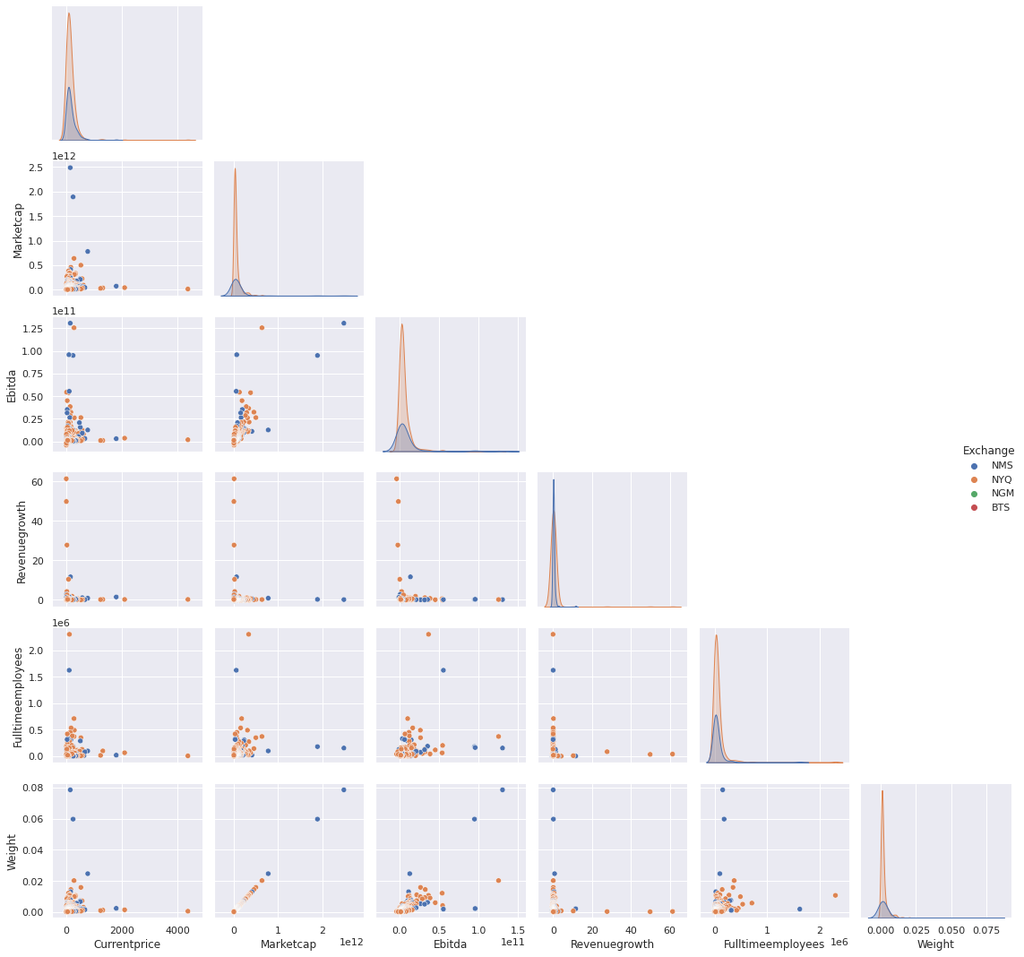

```python
sns.set(style='darkgrid')
plt.figure(figsize=(15,12))
sns.pairplot(SP500_Comp, corner=True, hue='Exchange')
plt.tight_layout()
```

#### *Observations*

- We can see a linear relationship between Marketcap and Weights (calculated from Marketcap).
- The distributions of these columns are mostly positively skewed, we'll get into the details of the distributions a bit later.

## 3.2. Correlation Heatmap [Table of contents🔝]]

> Correlation of any 2 variables quantifies the **linear** relationship between them. If 2 variables have low correlation with each other, that does not mean that they are independent of each other. They could influence each other, but it won't be linearly. They probably have non linear relationship with each other.

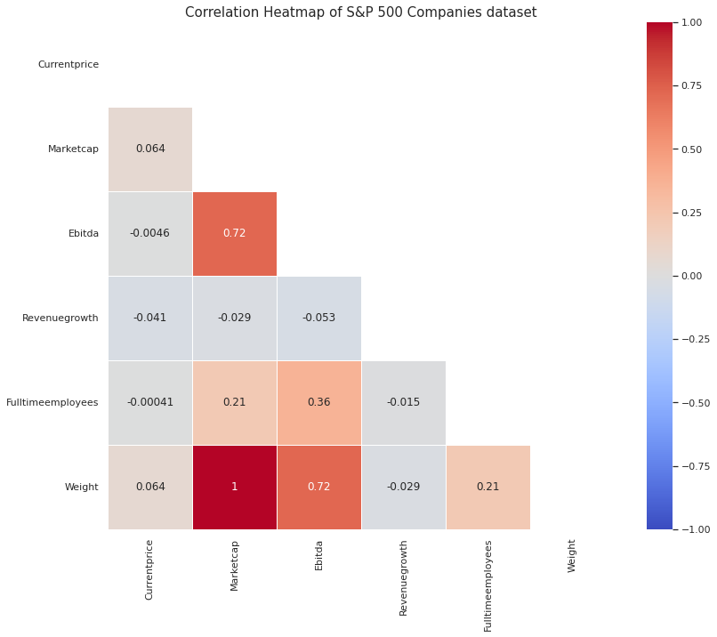

```python
SP_corr = SP500_Comp.corr()
mask = np.zeros_like(SP_corr)
mask[np.triu_indices_from(mask)] = True
with sns.axes_style("white"):
    f, ax = plt.subplots(figsize=(12, 10))
    ax = sns.heatmap(SP_corr, mask=mask, vmax=1, vmin=-1, linewidths=.5, square=True, cmap='coolwarm', annot=True)
    plt.title('Correlation Heatmap of S&P 500 Companies dataset', fontsize = 15)
    plt.yticks(rotation=0)
    plt.tight_layout()
```

##### *Observations:*

- As we can see, there's a high positive correlation = 1, between Marketcap & Weight, which has a very obvious reason, i.e., weights in S&P 500 are calculated using Marketcap. Formula: $weights = \dfrac{Company\:marker\:cap}{Total\:of\:all\:market\:cap}$
- EBITDA also shows a strong correlation with Weights as well, that is companies with higher weights, tend to show high EBITDA.
- Other features have weak positive or negative relationship with each other.

## 3.3. Distribution Analysis [Table of contents🔝]]

### 3.3.1. Distribution of Exchange column

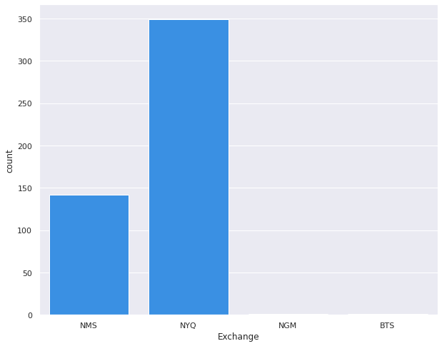

```python
plt.figure(figsize=(10,8))
d0 = sns.countplot(data=SP500_Comp, x='Exchange', color='dodgerblue')
```

#### *Observations*:

- Stocks in S&P 500 are exchaged the most at NYQ.

### 3.3.2. Distribution of Revenue Growth

```
(-0.7, 3.0)
```

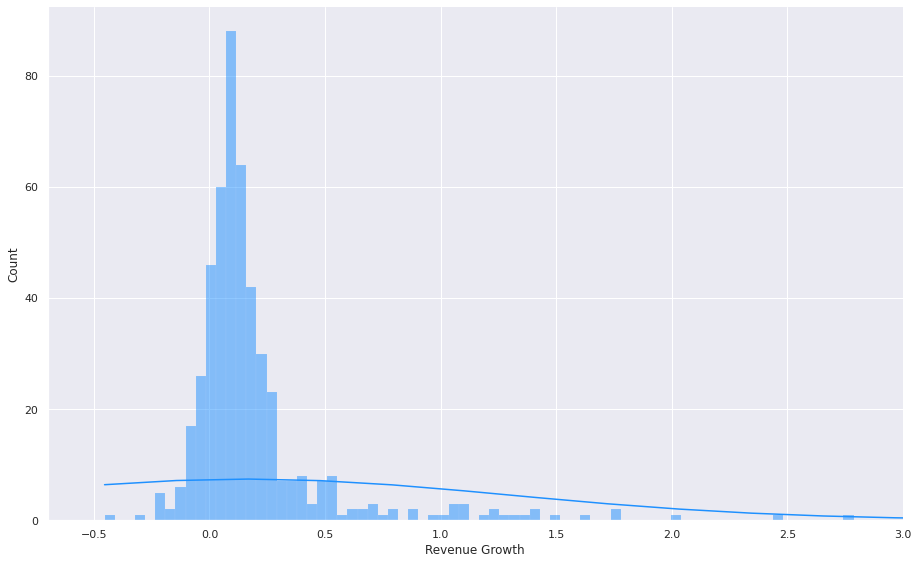

```python
d1 = sns.displot(data=SP500_Comp, x='Revenuegrowth', height=8, aspect=1.6, kde=True, color='dodgerblue')
d1.set(xlabel='Revenue Growth')
plt.xlim(-0.7,3)
```

### 3.3.3. Distribution of Current Price

```
(0.0, 2100.0)
```

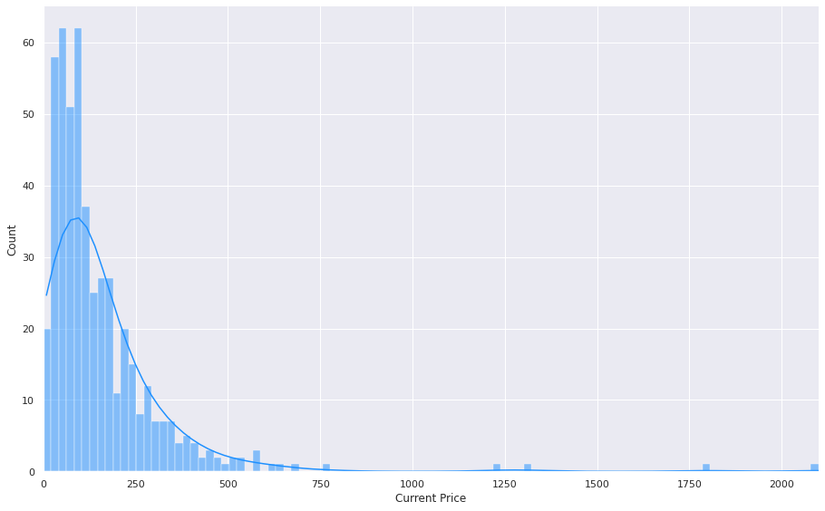

```python
d2 = sns.displot(data=SP500_Comp, x='Currentprice', kde=True, height=8, aspect=1.6, bins=100, binrange=(0, 2100), color='dodgerblue')
d2.set(xlabel='Current Price')
plt.xlim(0, 2100)
```

#### *Observations*

- The distribution of Current Price is skewed right that means, the vast majority of stocks in S&P 500 have low current price as compared to few minority stocks aka outliers seen on the right side of the plot.
- Also, there are seem to be 2 distinct groups that has the highest count of Current Price, which seems to be between 50-150.

```python
print(f'The mode of the Current Price column is {SP500_Comp.Currentprice.mode()[0]}.')
```

```
The mode of the Current Price column is 24.3.
```

### 3.3.4. Distribution of Full Time Employees

```
(0.0, 300000.0)
```

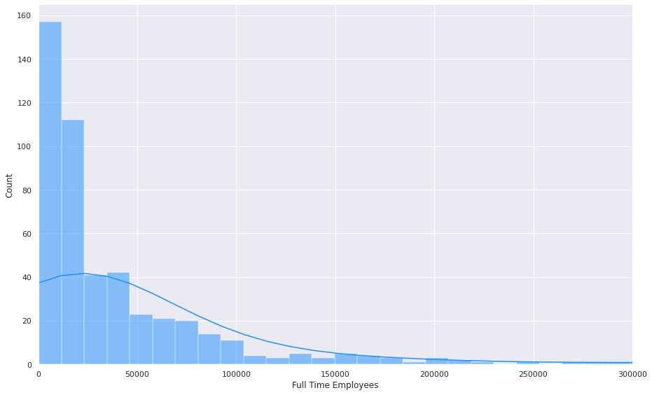

```python
d3 = sns.displot(data=SP500_Comp, x='Fulltimeemployees', height=8, aspect=1.6, bins=200, kde=True, color='dodgerblue')
d3.set(xlabel='Full Time Employees')
plt.xlim(0, 0.3*1e6)
```

#### *Observations*

```python
print(f'The mode of the Fulltimeemployees column is {SP500_Comp.Fulltimeemployees.mode()[0]}.')
```

```
The mode of the Fulltimeemployees column is 14000.0.
```

# 3.4. Questions to Ask [Table of contents🔝]]

### Q - Which is the leading sector in S&P 500?

The code below is referred from the notebook [Which stocks should I invest in?](https://www.kaggle.com/code/dhimananubhav/which-stocks-should-i-invest-in) by Anubhav Dhiman.

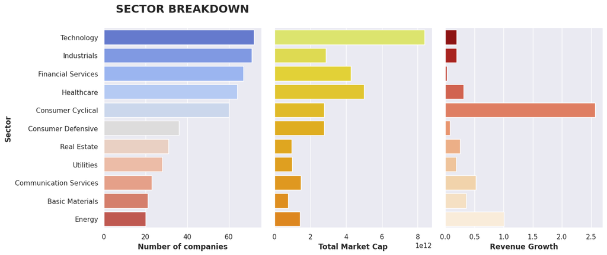

```python
f = {'Revenuegrowth':['mean'], 'Marketcap':['sum'], 'Longname':['count']}

sector_breakdown = SP500_Comp.groupby('Sector').agg(f)
sector_breakdown.columns = sector_breakdown.columns.get_level_values(0)
sector_breakdown = sector_breakdown.reset_index()
sector_breakdown = sector_breakdown.sort_values('Longname', ascending=False)

fig = plt.figure(num=None, figsize=(14, 6), dpi=100, facecolor='w', edgecolor='k')

plt.subplot(1, 3, 1)
ax1 = sns.barplot(x="Longname", y="Sector", data=sector_breakdown, palette=('coolwarm'))
ax1.set_xlabel('Number of companies', weight='bold')
ax1.set_ylabel('Sector', weight = 'bold')
ax1.set_title('SECTOR BREAKDOWN\n', weight='bold').set_fontsize('18')

plt.subplot(1, 3, 2)
ax2 = sns.barplot(x="Marketcap", y="Sector", data=sector_breakdown, palette=('Wistia'))
ax2.set_xlabel('Total Market Cap', weight='bold')
ax2.set_ylabel('')
ax2.set_yticks([])

plt.subplot(1, 3, 3)
ax2 = sns.barplot(x="Revenuegrowth", y="Sector", data=sector_breakdown, palette=('OrRd_r'))
ax2.set_xlabel('Revenue Growth', weight='bold')
ax2.set_ylabel('')
ax2.set_yticks([])

sns.despine()
plt.tight_layout();
```

#### *Observations:*

- In S&P 500, stocks in Technology Sector and the total Market Cap of this sector is the highest.
- On the other hand, Consumer Cyclical sector has the stocks with the most revenue growth.
- While the least amount of stocks belong to Energy sectors but has the 2nd highest revenue growth.

### Q: Where are most stocks tracked by S&P 500 exchanged at?

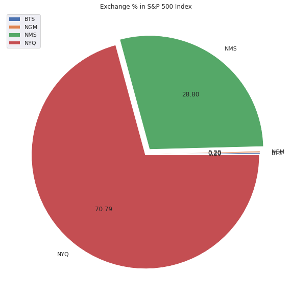

```python
# storing count values
exchange_df = (SP500_Comp.groupby(["Exchange"]).size().reset_index(name="Counts").sort_values(by=["Exchange"]))
labels = exchange_df['Exchange'].unique()
values = exchange_df['Counts']

plt.figure(figsize=(10,12))
fig1 = plt.pie(x=values, labels=labels,explode=[0,0,0.05,0.01], autopct='%.2f')
plt.legend()
plt.title('Exchange % in S&P 500 Index')
```

#### *Observations:*

- Most of the stocks tracked by S&P 500 i.e., 70.79%, are exchanged at NYQ.
- 28.8% of them are exchanged at NMS.
- The rest of the 0.4% are exchanged at NGM (0.2%) & BTS (0.2%), which is exactly one stock each.

```python
SP500_Comp[SP500_Comp['Exchange']=='BTS']
```

|  | Exchange | Symbol | Shortname | Longname | Sector | Industry | Currentprice | Marketcap | Ebitda | Revenuegrowth | City | Country | Fulltimeemployees | Longbusinesssummary | Weight |
| --- | --- | --- | --- | --- | --- | --- | --- | --- | --- | --- | --- | --- | --- | --- | --- |
| 412 | BTS | CBOE | Cboe Global Markets, Inc. | Cboe Global Markets, Inc. | Financial Services | Financial Data & Stock Exchanges | 125.08 | 13338906624 | 1.011500e+09 | -0.036 | Chicago | United States | 1196.0 | Cboe Global Markets, Inc., through its subsidi... | 0.000421 |

```python
SP500_Comp[SP500_Comp['Exchange']=='NGM']
```

|  | Exchange | Symbol | Shortname | Longname | Sector | Industry | Currentprice | Marketcap | Ebitda | Revenuegrowth | City | Country | Fulltimeemployees | Longbusinesssummary | Weight |
| --- | --- | --- | --- | --- | --- | --- | --- | --- | --- | --- | --- | --- | --- | --- | --- |
| 243 | NGM | ENPH | Enphase Energy, Inc. | Enphase Energy, Inc. | Technology | Solar | 216.1 | 29154484224 | 259260992.0 | 0.462 | Fremont | United States | 2260.0 | Enphase Energy, Inc., together with its subsid... | 0.000921 |

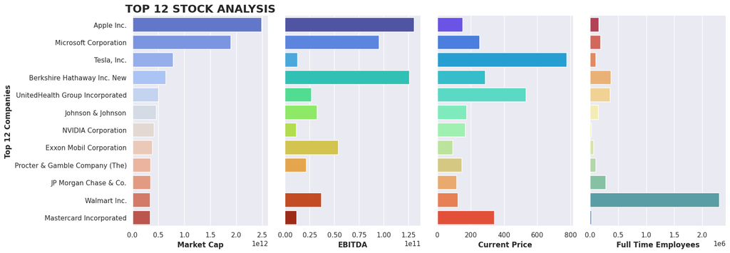

```python
N = 12
fig2 = plt.figure(num=None, figsize=(17, 6), dpi=100, facecolor='w', edgecolor='k')

plt.subplot(1, 4, 1)
ax1 = sns.barplot(x=SP500_Comp.iloc[:N,7], y=SP500_Comp.iloc[:N,2], data=SP500_Comp, palette=('coolwarm'))
ax1.set_xlabel('Market Cap', weight='bold')
ax1.set_ylabel(f'Top {N} Companies', weight = 'bold')
ax1.set_title(f'TOP {N} STOCK ANALYSIS', weight='bold').set_fontsize('18')

plt.subplot(1, 4, 2)
ax2 = sns.barplot(x=SP500_Comp.iloc[:N,8], y=SP500_Comp.iloc[:N,2], data=SP500_Comp, palette=('turbo'))
ax2.set_xlabel('EBITDA', weight='bold')
ax2.set_ylabel('')
ax2.set_yticks([])

plt.subplot(1, 4, 3)
ax2 = sns.barplot(x=SP500_Comp.iloc[:N,6], y=SP500_Comp.iloc[:N,2], data=SP500_Comp, palette=('rainbow'))
ax2.set_xlabel('Current Price', weight='bold')
ax2.set_ylabel('')
ax2.set_yticks([])

plt.subplot(1, 4, 4)
ax2 = sns.barplot(x=SP500_Comp.iloc[:N,12], y=SP500_Comp.iloc[:N,2], data=SP500_Comp, palette=('Spectral'))
ax2.set_xlabel('Full Time Employees', weight='bold')
ax2.set_ylabel('')
ax2.set_yticks([])

sns.despine()
plt.tight_layout();
```

#### Observations

- Apple Inc is the stock with the highest Market Cap, hence gaining the highest weight in S&P 500 Index and occupying the 1st spot. A high EBITDA means the company, aka Apple Inc. has less operating expenses, and higher earnings, which shows that they will still have a decent amount of revenue left over after their paying operating costs.
- It's Current Price is on the average side in the S&P 500 Index (between 100-200).

**Congratulations, you have made this far in the notebook!🤸🏻‍♀️ Thanks for checking this notebook. Do drop a comment or suggestions!⭐**  
P.S. I thought Kitty & Corgi mode would be distracting, but they weren't.

[figure not shown]